# Confiabilidad de sistemas industriales

Published

2025-04-10

# Tabla de Contenido

1. Introducción
2. Fundamentos de la evaluación de la confiabilidad en sistemas eléctricos
3. Probabilidad condicional
4. El caso continuo y la distribución normal
5. Medidas de tendencia central y de variabilidad
6. Dos grandes Teoremas
7. Material adicional

# 1. Introducción

#Objetivo

Describir la forma de realizar predicciones cuantitativas de confiabilidad y disponibilidad en configuraciones de sistemas de distribución de energía en la industria, teniendo en cuenta factores como índices de confiabilidad, datos de confiabilidad, definición de interrupciones y ecuaciones de confiabilidad. Además, se presentan ejemplos detallados de diferentes configuraciones de sistemas industriales para ilustrar cómo la falla de componentes afecta a la confiabilidad global en puntos de uso dentro de instalaciones industriales.

# 2. Fundamentos de la evaluación de la confiabilidad en sistemas eléctricos

# Índices de confiabilidad en sistemas eléctricos

Los índices básicos de confiabilidad del sistema (IEEE Std 493™-1997) que han demostrado ser más útiles y significativos en el diseño de sistemas de distribución de energía son los siguientes:

1. Frecuencia de interrupciones en puntos de carga.
2. Duración esperada de los eventos de interrupción en puntos de carga.

Estos índices se pueden calcular fácilmente utilizando los métodos que se describirán y referenciarán en este capítulo. Los dos índices básicos (**frecuencia de interrupciones y duración esperada de las interrupciones**) se pueden utilizar para calcular los siguientes índices que también son útiles en la planificación y diseño de sistemas de energía industriales y comerciales:

- Tiempo total esperado (promedio) de interrupción por año (u otro período de tiempo)
- Disponibilidad o indisponibilidad del sistema medida en el punto de suministro de carga en cuestión
- Energía esperada, pero no suministrada, por año

Estos índices son herramientas importantes para evaluar la confiabilidad y disponibilidad de los sistemas de distribución de energía y pueden ayudar en la toma de decisiones en el diseño y planificación de dichos sistemas en entornos industriales y comerciales.

Es importante tener en cuenta que el efecto disruptivo de las interrupciones de energía a menudo está relacionado de manera no lineal con la duración de la interrupción. Por lo tanto, a menudo es deseable calcular no solo una frecuencia general de interrupciones, sino también frecuencias de interrupciones categorizadas por las duraciones apropiadas. Esto permite una comprensión más detallada de cómo las interrupciones de energía afectan a un sistema en particular, considerando diferentes duraciones de interrupción y su impacto en la confiabilidad y disponibilidad del sistema.

#Que es una Interrupción?

Esta definición especifica la magnitud de la caída de voltaje y la duración mínima de ese período de voltaje reducido que resultaría en una pérdida de producción u otra función crítica para la planta, proceso o edificio en cuestión. Frecuentemente, las definiciones de interrupción se dan solo en términos de una duración mínima y asumen que el voltaje es cero durante ese período. Establecer una definición clara y bien definida de interrupción es un paso crucial en la evaluación de la confiabilidad, ya que sirve de base para recopilar y analizar datos de interrupciones, calcular índices de confiabilidad y tomar decisiones informadas sobre el diseño, mantenimiento y estrategias de mejora del sistema.

Para el curso, cómo establecemos una interrupción ? CREG ?

Instantáneas (menor a 1 min)

Transitorias (1-5) min

Temporales (mayor a 5 min)

#Definición de la interrupción del servicio

La primera etapa en un estudio de confiabilidad de un sistema eléctrico de suministro de energía es evaluar cuidadosamente la calidad y continuidad del suministro de energía requerido por las cargas que deben ser atendidas. Esta evaluación se resume y se expresa en una definición de interrupción del servicio que se utilizará en los pasos siguientes del proceso de evaluación de confiabilidad.

#Datos requeridos para la evaluación de la confiabilidad en sistemas La información necesaria para las evaluaciones cuantitativas de la confiabilidad de un sistema depende en cierta medida de la naturaleza del sistema estudiado y del nivel de detalle de la investigación. En general, sin embargo, los datos sobre el rendimiento de los componentes individuales, junto con los tiempos requeridos para realizar reparaciones o reemplazos, así como los tiempos de operaciones de conmutación, se resumen de la siguiente manera:

1. Tasas de falla (tasas de salida forzada) asociadas con diferentes modos de falla de los componentes.
2. Tiempo esperado (promedio) para reparar o reemplazar un componente fallido.
3. Tasa de interrupción programada (mantenimiento) de un componente.
4. Duración esperada (promedio) de un evento de interrupción programada.

Los datos de tiempo necesarios para las operaciones de conmutación manual o automática incluyen lo siguiente:

1. Tiempos esperados para abrir y cerrar un interruptor de circuito.
2. Tiempos esperados para abrir y cerrar un interruptor de desconexión o transferencia.
3. Tiempo esperado para reemplazar un fusible.
4. Tiempos esperados para realizar operaciones de emergencia.

Los tiempos de conmutación deben estimarse para el sistema que se está estudiando en función de la experiencia, juicio de ingeniería y prácticas operativas anticipadas.

**Si es posible, los datos de los componentes deben basarse en el rendimiento histórico de componentes en un entorno similar al del sistema propuesto que se está estudiando.**

#Métodos para la evaluación de la confiabilidad

Hoy en día existen numerosas metodologías de confiabilidad informática disponibles para analizar configuraciones complejas de sistemas de energía industrial y comercial. En particular, en el curso nos centraremos en el uso de ETAP.

El método de conjunto mínimo de cortes se utilizará en el análisis de varios sistemas de distribución de energía eléctrica. El método es sistemático y directo, y se puede realizar tanto manualmente como con el uso de computadoras. Una característica importante de este método es que permite identificar fácilmente los puntos débiles del sistema, tanto numérica como no numéricamente, lo que permite centrar la atención del diseño en aquellas secciones o componentes del sistema que contribuyen más a la falta de confiabilidad del servicio.

Uno de los principales beneficios de un análisis de confiabilidad y disponibilidad es que se realiza un análisis disciplinado de las opciones alternativas en el diseño del sistema de distribución de energía. Al utilizar datos de confiabilidad publicados recopilados por una sociedad técnica de plantas industriales, se realiza el mejor intento posible de utilizar la experiencia histórica para ayudar en el diseño del nuevo sistema.

# Procedimiento Evaluación de la confiabilidad y disponibilidad de un sistema de potencia industrial de baja tensión

Consideraciones:

- Solo se consideran fallas permanentes forzadas del equipo eléctrico
- Se asume que el mantenimiento programado se realizará en momentos en los que no se requiere salida de energía a 480V
- La frecuencia de las fallas programadas y la duración promedio se pueden estimar y, si es necesario, se pueden agregar a las fallas forzadas dadas.
- Se considera una falla en el suministro de energía al punto de utilización de 480 V
- Interrupción: Pérdida completa de la energía de entrada durante más de 5 segundos.
- Interrupción del servicio: Esta definición de falla/interrupción puede tener un efecto en la determinación de la velocidad necesaria del equipo de transferencia automática que se utiliza en sistemas primarios-selectivos o secundarios-selectivos. En algunos casos, al realizar estudios de confiabilidad, puede ser necesario definir más detalladamente qué se considera una pérdida completa de energía entrante, por ejemplo, una caída de voltaje por debajo del 70%.

$λ$ = Tasa de falla (fallas por año)

$r$ = El tiempo promedio de inactividad por falla (horas por falla) es igual al tiempo promedio necesario para reparar o reemplazar un equipo después de una falla. En algunos casos, esto incluye el tiempo necesario para cambiar a un circuito alternativo cuando está disponible.

##Procedimiento para el análisis de la confiabilidad y disponibilidad

**Def**: La tasa de falla $λ$ es una medida de la falta de confiabilidad. El producto $λr$ (tasa de falla por tiempo promedio de inactividad por falla) es igual a las horas de inactividad forzada por año y puede considerarse una medida de la indisponibilidad forzada, ya que un factor de escala de 8760 convierte una cantidad en la otra. El tiempo promedio de inactividad por falla $r$ podría llamarse capacidad de restauración.

En los ejemplos (serie y paralelo), se asume que las interrupciones programadas son cero y las unidades para $λ$ y $r$ son, respectivamente, fallas por año y horas de inactividad por falla.

Se lo siguiente:

- La tasa de falla de los componentes es constante con la edad.
- El tiempo de interrupción después de una falla tiene una distribución exponencial.
- Cada evento de falla es independiente de cualquier otro evento de falla.
- Los tiempos de funcionamiento de los componentes son mucho mayores que los tiempos de falla: $λ_ir_i$ / 8760 < 0.01.

Notación:

$f$ = Frecuencia de fallas

$r_i$ = Promedio de horas de tiempo de inactividad por falla para el i-ésimo componente

$s$ = En serie

$p$ = En paralelo

Para los componentes en serie, se tiene:

$$f_s = λ_1 + λ_2$$

$$f_{s}r_s = λ_1r_1 + λ_2r_2$$

$$rs \cong = \frac{λ_1r_1 + λ_2r_2}{λ_1 + λ_2 }$$

$$f_p = \frac{λ_3 λ_4 (r_3 + r_4) }{8760}$$

$$f_{p}r_p = \frac{λ_3r_3 λ_4 r_4 }{8760}$$

$$rp = \frac{ r_3 r_4 }{ r_3 + r_4}$$

- son aproximados y solo deben ser utilizados cuando ambos $(λ3r3 / 8760)$ y $(λ4r4 / 8760)$ sean menores a 0.01.

disponibilidad inherente (Ai): La probabilidad instantánea de que un componente o sistema esté operativo o inoperativo. Ai solo considera el tiempo de inactividad debido a reparaciones de fallas. No se incluye el tiempo logístico, el mantenimiento preventivo, etc

#Confiabilidad del suministro de energía eléctrica de las empresas de servicios públicos a plantas industriales.

La tasa de falla y el tiempo promedio de inactividad por falla de los suministros de energía eléctrica de las empresas de servicios públicos se proporcionan en la Tabla 3-1. Esto incluye datos de confiabilidad tanto para circuitos individuales como para circuitos dobles. Las dos fuentes de energía en un suministro de energía eléctrica de circuito doble no son completamente independientes, y el análisis de confiabilidad y disponibilidad debe tener esto en cuenta.

Una falla de un componente en la planta causa una indisponibilidad forzada del componente; es decir, el componente no puede cumplir su función prevista hasta que sea reparado o reemplazado. Los términos “falla” e “indisponibilidad forzada” a menudo se usan indistintamente para referirse a estos eventos.

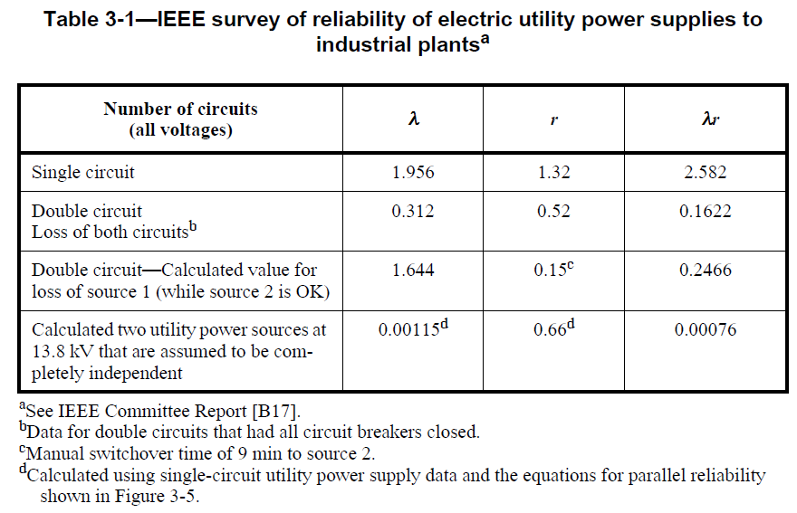

Los datos de confiabilidad sobre los modos de falla de los interruptores de circuito se muestran en la Tabla 3-2. Estos datos se utilizan para los interruptores de circuito de 480 V. Se asumirá que el modo de falla “arco mientras está abierto” para interruptores de circuito y desconectadores tiene una tasa de falla de 0.0.

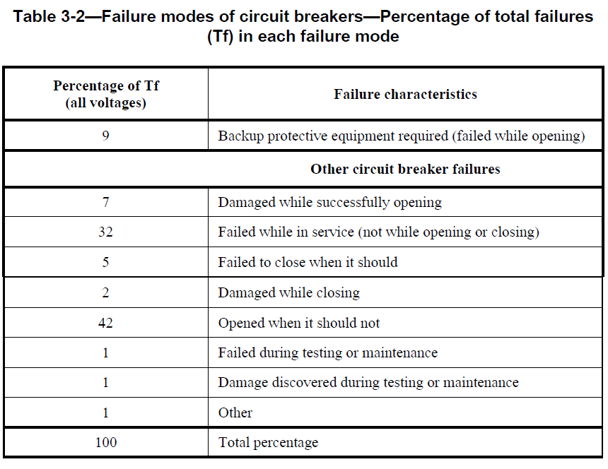

#Ejemplo 1: Análisis de conafiabilidad y disponibilidad de un sistema radial simple

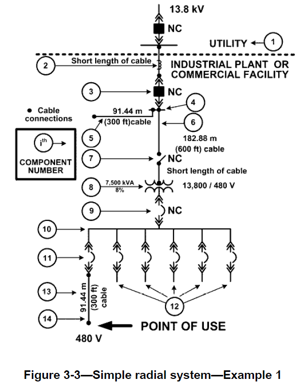

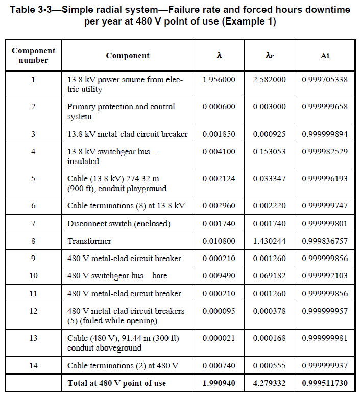